# InstaCart Predictive Analysis: Products

April Leclair, Daniel Ochoa, Hoang Anh Thai Vu, Qiuhan Sun

This file provides some exploratory analysis of the InstaCart data products, aisles and departments.

# Reading in the data

Instead of sampling, we will use the sample40 data to explore the characteristics of products.

```r
aisles = read_csv("../Source/aisles.csv")
departments = read_csv("../Source/departments.csv")
products = read_csv("../Source/products.csv")
order_products_prior40 <- read_csv("../Source/order_products_sample40.csv") %>%
  subset(select=-X1)
order_products_train <- read_csv("../Source/order_products__train.csv")
orders40 = read_csv("../Source/orders_sample40.csv")
```

# Preparing the data for training

Filtering out only priors data for train subset

```r
# Filter out the orders would lead the final evaluation of 'train' (instead of test eval)
train_users <- subset(orders40,eval_set=='train')
orders40 <- orders40%>%
  mutate(order_dow = factor(order_dow, levels=c("Sunday","Monday","Tuesday","Wednesday","Thurday","Friday","Saturday")))
orders40_train <- orders40%>%
  filter(user_id %in% train_users$user_id)
# Prios data for train set
order_products_trprior40 <- subset(order_products_prior40, order_id %in% unique(orders40_train$order_id))
```

Create the testing data from training set

```r
order_products_train40 <- subset(order_products_train, order_id %in% unique(orders40$order_id))

# Remove excess datasets
rm(order_products_train,order_products_prior40,orders40)
```

# Merging all product related configure

```r
warehouse <- products%>%
  left_join(departments)%>%
  left_join(aisles)%>%
  mutate(department=as.factor(department))

inventory <- warehouse%>%
  group_by(department,aisle)%>%
  summarise(total=n())%>%
  arrange(desc(total))

orders_details_trprior40 <- left_join(order_products_trprior40,warehouse)
```

# Choosing one specific user to conduct analysis

We are going to look at the behaviors of one particular user to conduct a predictive analysis on the products he/she would order.

First of all, let’s take a look at the users ranked by the number of orders they have made in the sample set. Note that due to the way InstaCart selected these dataset, the number of orders for each user range from 4 to 100.

```r
top_users <- orders40_train %>%
  group_by(user_id)%>%
  summarise(total_orders=n(),total_days=sum(days_since_prior_order))%>%
  arrange(desc(total_orders))
```

Table 1: Top 20 Users with Most Orders

| user_id | total_orders | total_days |
| --- | --- | --- |
| 210 | 100 | NA |
| 2405 | 100 | NA |
| 4284 | 100 | NA |
| 4711 | 100 | NA |
| 5912 | 100 | NA |
| 6448 | 100 | NA |
| 8832 | 100 | NA |
| 9106 | 100 | NA |
| 9911 | 100 | NA |
| 10747 | 100 | NA |
| 11845 | 100 | NA |
| 12473 | 100 | NA |
| 13335 | 100 | NA |
| 14230 | 100 | NA |
| 15124 | 100 | NA |
| 16265 | 100 | NA |
| 16357 | 100 | NA |
| 16645 | 100 | NA |
| 21777 | 100 | NA |
| 22274 | 100 | NA |

We are going to look at the first one that showed up: the user with `user_id` of 210.

```r
user210_orders <- subset(orders40_train,user_id==210)
user210_products_prior <- subset(order_products_trprior40,order_id %in% user210_orders$order_id)
user210_products_train <- subset(order_products_train40,order_id %in% user210_orders$order_id)
user210_prior_details <- left_join(user210_products_prior,user210_orders) %>%
  left_join(warehouse)%>%
  select(-X1,-eval_set,-user_id,-aisle_id,-department_id)
```

The table below consists of information about department in each order the User210 made.

```r
user210_prior_department <- user210_prior_details%>%
  select(order_number,department,order_dow,order_hour_of_day,days_since_prior_order)%>%
  group_by(order_number,department,order_dow,order_hour_of_day,days_since_prior_order)%>%
  summarise(count=n())%>%
  group_by(order_number)%>%
  mutate(total=sum(count),percentage=count/total)
```

Table 2: User 210 Product Department Summary

| order_number | department | order_dow | order_hour_of_day | days_since_prior_order | count | total | percentage |
| --- | --- | --- | --- | --- | --- | --- | --- |
| 1 | dairy eggs | Sunday | 12 | NA | 2 | 7 | 0.2857143 |
| 1 | pantry | Sunday | 12 | NA | 2 | 7 | 0.2857143 |
| 1 | produce | Sunday | 12 | NA | 3 | 7 | 0.4285714 |
| 2 | breakfast | Wednesday | 07 | 3 | 1 | 4 | 0.2500000 |
| 2 | dairy eggs | Wednesday | 07 | 3 | 1 | 4 | 0.2500000 |
| 2 | produce | Wednesday | 07 | 3 | 2 | 4 | 0.5000000 |
| 3 | deli | Saturday | 11 | 3 | 3 | 8 | 0.3750000 |
| 3 | frozen | Saturday | 11 | 3 | 1 | 8 | 0.1250000 |
| 3 | produce | Saturday | 11 | 3 | 4 | 8 | 0.5000000 |

Since it is likely that a user behavior will be somewhat consistent (habits), we expect the percentage of each department ordered could be predicted based on Day of Week, Hour of Day, and Total amount of Order.

Here is the visualization on the dataset. We could observe that the behaviour is indeed quite consistent and predictable

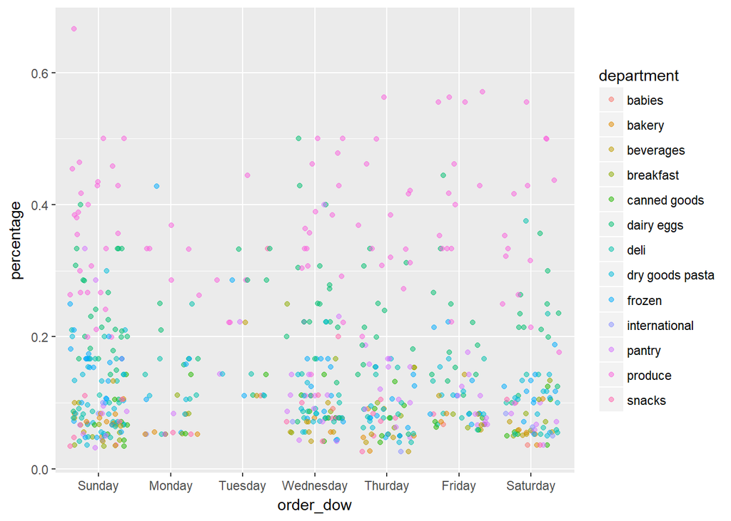

```r
ggplot(user210_prior_department,aes(x=order_dow,y=percentage,color=department))+
  geom_jitter(alpha=0.5)
```

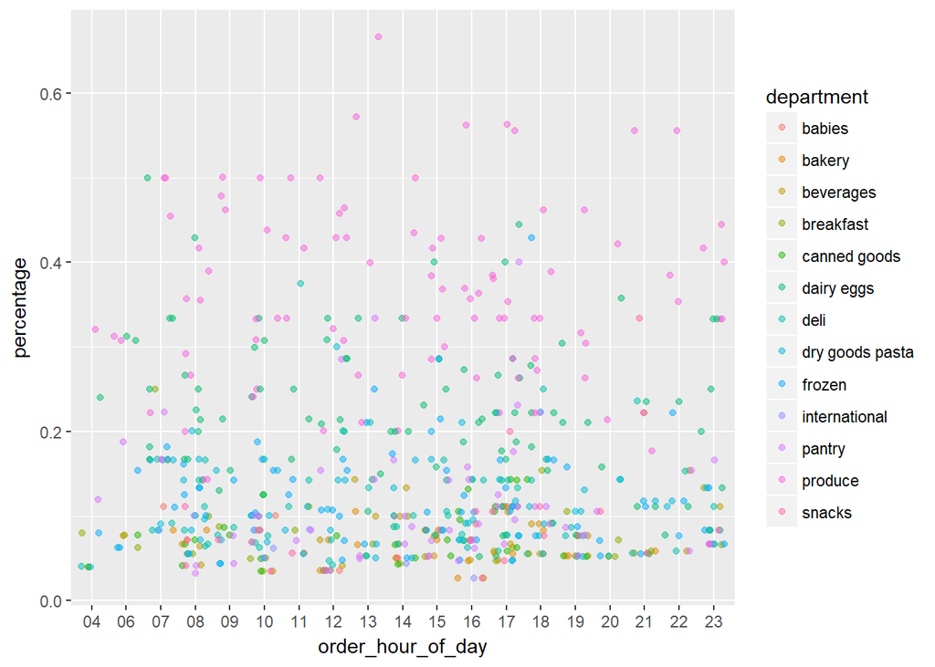

```r
ggplot(user210_prior_department,aes(x=order_hour_of_day,y=percentage,color=department))+
  geom_jitter(alpha=0.5)
```

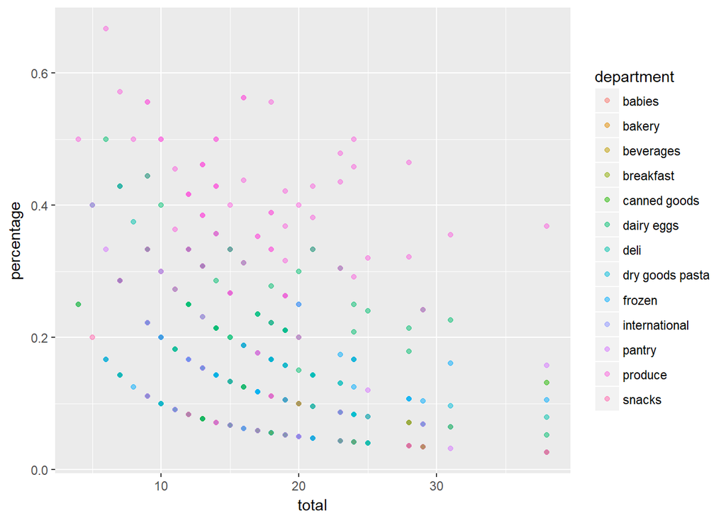

```r
ggplot(user210_prior_department,aes(x=total,y=percentage,color=department))+
  geom_point(alpha=0.5)
```

# Department Predictive Analysis – Data Prep

```r
user210_prior_department70 <- user210_prior_department%>%
  subset(order_number<71)%>%
  ungroup
user210_prior_department29 <- user210_prior_department%>%
  subset(70<order_number&order_number<100)%>%
  ungroup
```

# Department Predictive Analysis – Regression

```r
lm1=lm(percentage~order_dow+total+department,user210_prior_department70)
summary(lm1)
```

```
##
## Call:
## lm(formula = percentage ~ order_dow + total + department, data = user210_prior_department70)
##
## Residuals:
##      Min       1Q   Median       3Q      Max
## -0.27090 -0.04030 -0.01074  0.02664  0.26364
##
## Coefficients:
##                            Estimate Std. Error t value Pr(>|t|)
## (Intercept)                0.161513   0.039412   4.098 5.03e-05 ***
## order_dowMonday           -0.004038   0.016071  -0.251 0.801731
## order_dowTuesday          -0.010035   0.018060  -0.556 0.578752
## order_dowWednesday        -0.005966   0.011559  -0.516 0.606024
## order_dowThurday          -0.017666   0.013177  -1.341 0.180759
## order_dowFriday           -0.013698   0.011732  -1.168 0.243676
## order_dowSaturday         -0.007703   0.010843  -0.710 0.477854
## total                     -0.005332   0.000750  -7.110 5.26e-12 ***
## departmentbakery           0.006517   0.040331   0.162 0.871711
## departmentbeverages        0.012447   0.040161   0.310 0.756770
## departmentbreakfast        0.018593   0.040037   0.464 0.642605
## departmentcanned goods     0.013682   0.039847   0.343 0.731500
## departmentdairy eggs       0.148658   0.037897   3.923 0.000103 ***
## departmentdeli             0.040438   0.038486   1.051 0.294010
## departmentdry goods pasta  0.035342   0.038565   0.916 0.359980
## departmentfrozen           0.044782   0.038355   1.168 0.243672
## departmentinternational   -0.005910   0.049609  -0.119 0.905231
## departmentpantry           0.045455   0.038656   1.176 0.240330
## departmentproduce          0.274458   0.037893   7.243 2.22e-12 ***
## departmentsnacks           0.028218   0.041583   0.679 0.497779
## ---
## Signif. codes:  0 '***' 0.001 '**' 0.01 '*' 0.05 '.' 0.1 ' ' 1
##
## Residual standard error: 0.07328 on 406 degrees of freedom
## Multiple R-squared:  0.662,  Adjusted R-squared:  0.6462
## F-statistic: 41.85 on 19 and 406 DF,  p-value: < 2.2e-16
```

# Department Predictive Analysis – Decision Tree

1. Tree of: `percentage~department`

```r
set.seed(3)
tree1<-tree(percentage~department,
            data=user210_prior_department70)
summary(tree1)
```

```
##
## Regression tree:
## tree(formula = percentage ~ department, data = user210_prior_department70)
## Number of terminal nodes:  4
## Residual mean deviance:  0.00596 = 2.515 / 422
## Distribution of residuals:
##     Min.  1st Qu.   Median     Mean  3rd Qu.     Max.
## -0.24530 -0.04120 -0.01210  0.00000  0.02822  0.31050
```

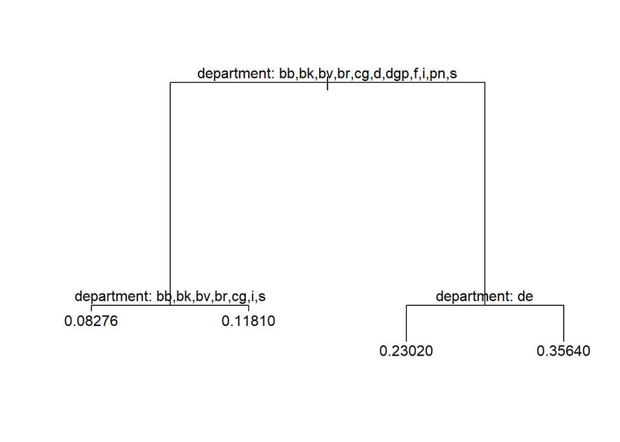

```r
plot(tree1)
text(tree1,pretty=1)
```

2. Tree of: `percentage~department+total+order_dow`

```r
set.seed(30)
tree2<-tree(percentage~department+total+order_dow,
            data=user210_prior_department70)
summary(tree2)
```

```
##
## Regression tree:
## tree(formula = percentage ~ department + total + order_dow, data = user210_prior_department70)
## Number of terminal nodes:  7
## Residual mean deviance:  0.004991 = 2.091 / 419
## Distribution of residuals:
##     Min.  1st Qu.   Median     Mean  3rd Qu.     Max.
## -0.22890 -0.03661 -0.01653  0.00000  0.02969  0.32660
```

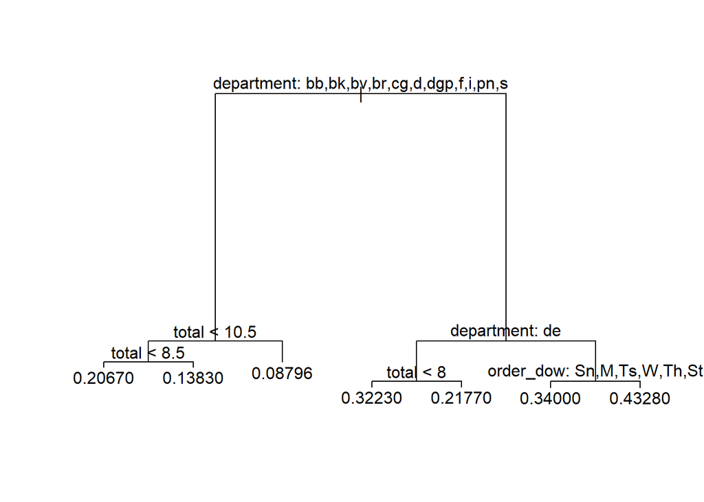

```r
plot(tree2)
text(tree2,pretty=1)
```

# Department Predictive Analysis – Random Forest

```r
set.seed(300)
forest1 <- randomForest(percentage~department,user210_prior_department70)
```

```r
set.seed(300)
forest2 <- randomForest(percentage~department+order_dow+total,user210_prior_department70)
```

# Visualization

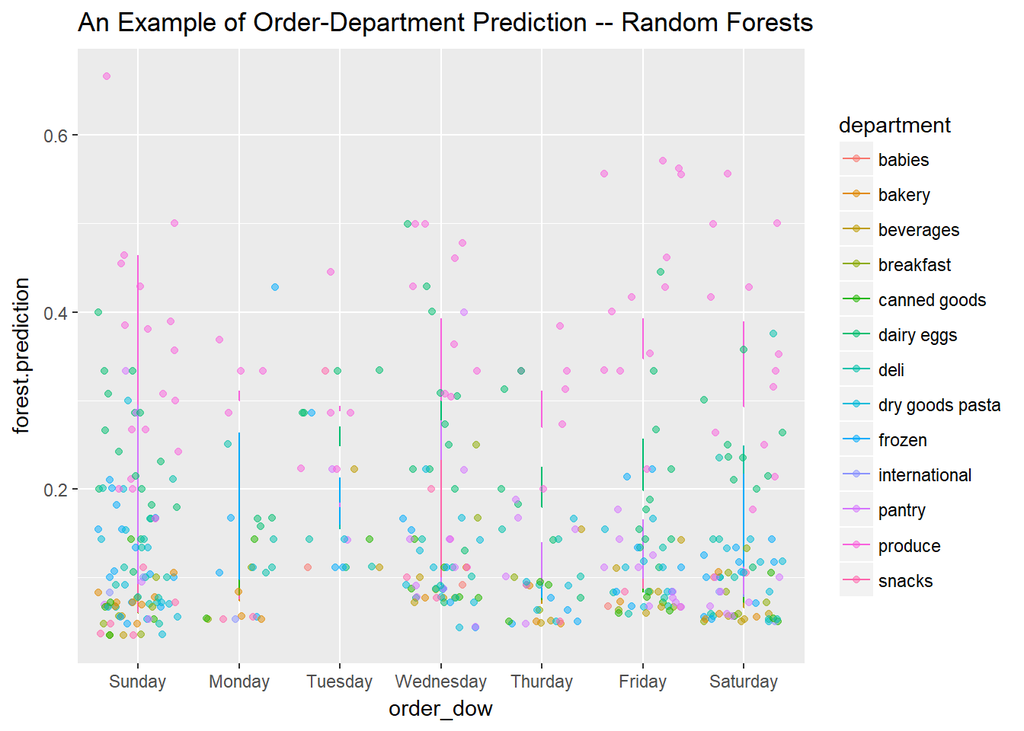

```r
forest.pred <- predict(forest2, user210_prior_department70)
user210_prior_department70 <- user210_prior_department70 %>%
    mutate(forest.prediction=forest.pred)
ggplot(user210_prior_department70, aes(y=forest.prediction, x=order_dow, color=department)) +
    geom_line()+
    geom_jitter(aes(y=percentage, x=order_dow, color=department), alpha=0.5)+
    labs(title="An Example of Order-Department Prediction -- Random Forests")
```

# Testing and Results

```r
lmtest <- predict(lm1, user210_prior_department29)
tree1test <- predict(tree1, user210_prior_department29)
tree2test <- predict(tree2, user210_prior_department29)
forest1test <- predict(forest1, user210_prior_department29)
forest2test <- predict(forest2, user210_prior_department29)


TestResults <- user210_prior_department29 %>%
    mutate(lmtest, tree1test)%>%
    mutate(lmError=(percentage-lmtest), tree1Error=(percentage-tree1test),
           tree2Error=(percentage-tree2test),forest1Error=(percentage-forest1test), forest2Error=(percentage-forest2test))
mean(TestResults$lmError^2)
```

```
## [1] 0.003899513
```

```r
mean(TestResults$tree1Error^2)
```

```
## [1] 0.003248294
```

```r
mean(TestResults$tree2Error^2)
```

```
## [1] 0.003434653
```

```r
mean(TestResults$forest1Error^2)
```

```
## [1] 0.00323927
```

```r
mean(TestResults$forest2Error^2)
```

```
## [1] 0.003752003
```